# DMML 2024: Final Project

## Random Forest Emotion

In questa sezione, abbiamo esplorato l'utilizzo dei **metodi ensemble**, che migliorano l'accuratezza delle predizioni aggregando i risultati di più classificatori, basandosi sul concetto di **"wisdom of the crowd"**. Uno di questi metodi ensemble è il **RandomForest**, che combina le previsioni di numerosi Decision Tree. Per ogni attributo, il RandomForest restituisce la moda dei risultati ottenuti dai vari alberi di decisione e questo tende a migliorare l'accuratezza e la robustezza del modello riducendo il rischio di overfitting. Questo metodo è particolarmente efficace perché sfrutta la diversità tra gli alberi di decisione, ognuno dei quali è addestrato su un sottoinsieme casuale dei dati (**bootstrap sampling**) e caratteristiche, selezionate anche loro in maniera casuale. Applicheremo lo stesso approccio che abbiamo utilizzato con il Decision Tree per prevedere 'Emotion'.

```python
from sklearn.ensemble import RandomForestClassifier
target = 'Emotion_val'
columns = [c for c in dfe_noobj.columns if c not in target]
```

```python
X = dfe_noobj[columns].values
Y = dfe_noobj[target].values
```

```python
X_train_val, X_test, y_train_val, y_test = train_test_split(X, y, test_size=0.2, stratify=y, random_state=0)
X_train, X_val, y_train, y_val = train_test_split(X_train_val, y_train_val, test_size=0.2, stratify=y_train_val, random_state=0)
```

```python
clf = RandomForestClassifier (criterion='gini',
    max_depth=11,
    min_samples_split=11,
    min_samples_leaf=3,
    ccp_alpha=0.0,
    random_state=0
)

param_dict = {
    'max_depth': np.arange(1, 20+1, 1).tolist(),
    'min_samples_split': np.arange(2, 50+1, 1),
    'min_samples_leaf': np.arange(1, 50+1, 1),
    'ccp_alpha': np.arange(0.0,1, 0.1)
}

random = RandomizedSearchCV(clf, param_dict, cv=5, scoring='accuracy', refit=True, n_iter=500, random_state=0)
random.fit(X_train_val, y_train_val)
random.best_params_

best_params = random.best_params_

clf = random.best_estimator_

clf.fit(X_train, y_train)
```

```
RandomForestClassifier(max_depth=16, min_samples_leaf=5, min_samples_split=6,
                       random_state=0)
```

L'accuratezza calcolata per il modello RandomForest è **0.49** e quindi superiore rispetto ai modelli Decision Tree e KNN. Questo evidenzia la potenza dell'approccio ensemble, in particolare la capacità del RandomForest di aggregare le previsioni di molti alberi decisionali per ridurre il rischio di overfitting e gestire efficacemente la varianza. Possiamo notare che questo modello mostra un'alta accuratezza nella previsione delle emozioni 'angry' e 'calm' (similarmente ai modelli precedenti ma con un aumento significativo), e dimostra anche un notevole miglioramento per le emozioni 'fearful' e 'surprised' rispetto al KNN e al Decision Tree. Questo sembra dimostrare la robustezza del RandomForest nel catturare le differenze di dati che caratterizzano queste emozioni specifiche. Al contrario, le emozioni 'disgust', 'sad' e 'neutral' registrano una precisione più bassa.

```python
y_pred = clf.predict(X_test)
y_pred_trainval = clf.predict(X_train_val)

accuracy = accuracy_score(y_test, y_pred)
print(accuracy)

print(classification_report(y_pred, y_test))
print(classification_report(y_pred_trainval, y_train_val))
```

```
0.48676171079429736
              precision    recall  f1-score   support

           0       0.80      0.66      0.72        91
           1       0.83      0.50      0.62       124
           2       0.26      0.53      0.34        19
           3       0.32      0.56      0.41        43
           4       0.36      0.39      0.37        70
           5       0.29      0.23      0.26        48
           6       0.27      0.40      0.32        50
           7       0.64      0.54      0.59        46

    accuracy                           0.49       491
   macro avg       0.47      0.48      0.45       491
weighted avg       0.56      0.49      0.51       491

              precision    recall  f1-score   support

           0       0.93      0.87      0.90       319
           1       0.92      0.76      0.83       365
           2       0.75      0.89      0.82       129
           3       0.81      0.86      0.83       284
           4       0.82      0.80      0.81       310
           5       0.80      0.84      0.82       143
           6       0.76      0.87      0.81       262
           7       0.79      0.81      0.80       149

    accuracy                           0.83      1961
   macro avg       0.82      0.84      0.83      1961
weighted avg       0.84      0.83      0.83      1961
```

Dall'analisi della **Feature Importance** del Random Forest si può notare che le variabili *min,max,length_ms* sono le più importanti per prevedere le Emozioni.

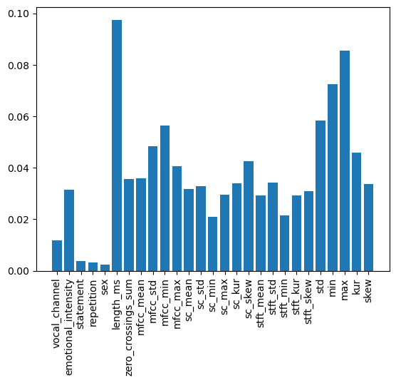

```python
plt.bar(columns, clf.feature_importances_)
plt.xticks(rotation=90)
plt.show()
```

Vediamo adesso quanti sono i DecisionTrees usati per creare la RandomForest (100) e ne visualizziamo due (il primo e il secondo)

```python
len(clf.estimators_)
```

```
100
```

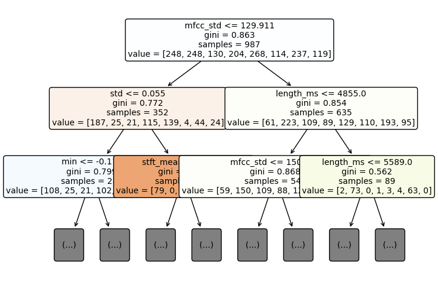

```python
plt.figure(figsize=(8, 6))
plot_tree(clf.estimators_[0],
          feature_names=columns,
          filled=True,
          rounded=True,
          fontsize=10,
          max_depth=2
          )
plt.show()
```

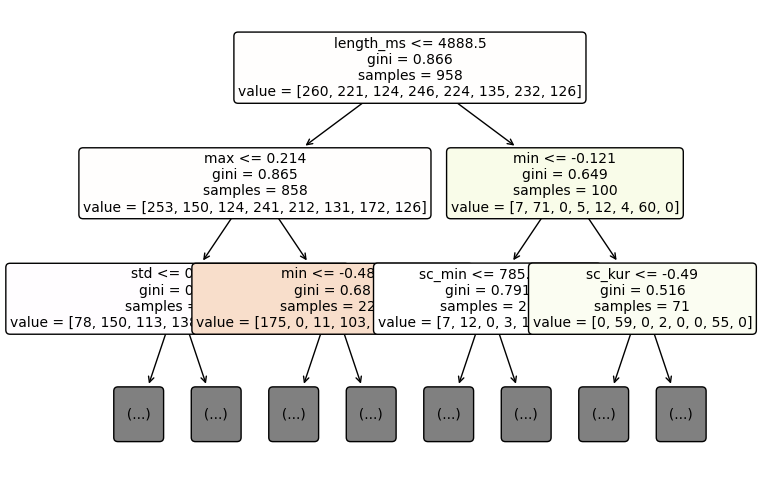

```python
plt.figure(figsize=(8, 6))
plot_tree(clf.estimators_[1],
          feature_names=columns,
          #class_names=clf.classes_,
          filled=True,
          rounded=True,
          fontsize=10,
          max_depth=2
          )
plt.show()
```

Nelle celle sotto abbiamo stampato la confusion matrix e plottato la ROC curve

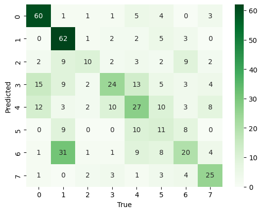

```python
import seaborn as sns
cf = confusion_matrix(y_test, y_pred)
sns.heatmap(cf, annot=True, cmap="Greens")
plt.xlabel("True")
plt.ylabel("Predicted")
plt.show()
```

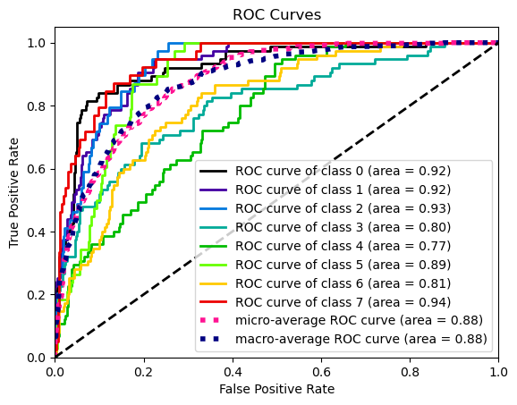

```python
import scikitplot
y_pred_proba = clf.predict_proba(X_test)
scikitplot.metrics.plot_roc(y_test,y_pred_proba)
```

## Random Forest con class_weight

La variabile target *emotion* è sbilaciata nel nostro dataset nel senso che i campioni dove la emotion è surprised, disgust e neutral sono sotto rappresentati:

| Emotion | Samples |
| --- | --- |
| fearful | 376 |
| angry | 376 |
| happy | 376 |
| calm | 376 |
| sad | 376 |
| surprised | 192 |
| disgust | 192 |
| neutral | 188 |

*0=angry,1=calm,2=disgust,3=Fearful,4=happy,5=Neutral,6=sad,7=surprised*.

Questo potrebbe portare il modello predittivo a essere sbilanciato verso la previsione delle classi più frequenti, potenzialmente ignorando le classi minoritarie. Ciò può causare scarse prestazioni, specialmente in termini della capacità del modello di identificare correttamente le istanze delle classi meno rappresentate. Mentre nel caso di surprised (7) il problema non sembra sussistere usando il Random Forest, le altre due classi minoritarie (disgust e neutral) sono effettivamente quelle dove il Random Forest ha la precisione più bassa. Per affrontare questo problema, aggiungiamo quindi il parametro **class_weight** alla Randomized Search lo settiamo a *balanced* che imposta il peso di ogni classe in maniera inversamente proporzionale alla frequenza di quella classe.

```python
from sklearn.metrics import accuracy_score
from sklearn.model_selection import RandomizedSearchCV
```

```python
clf = RandomForestClassifier (criterion='gini',
    max_depth=11,
    min_samples_split=11,
    min_samples_leaf=3,
    ccp_alpha=0.0,
    random_state=0
)

param_dict = {
    'max_depth': np.arange(1, 20+1, 1).tolist(),
    'min_samples_split': np.arange(2, 50+1, 1),
    'min_samples_leaf': np.arange(1, 50+1, 1),
    'ccp_alpha': np.arange(0.0,1, 0.1),
    'class_weight':['balanced']
}

random = RandomizedSearchCV(clf, param_dict, cv=5, scoring='accuracy', refit=True, n_iter=500, random_state=0)
random.fit(X_train_val, y_train_val)
random.best_params_

best_params = random.best_params_

clf = random.best_estimator_

clf.fit(X_train, y_train)
```

```
RandomForestClassifier(class_weight='balanced', max_depth=16,
                       min_samples_leaf=5, min_samples_split=6, random_state=0)
```

```python
from sklearn.metrics import classification_report
y_pred = clf.predict(X_test)
y_pred_trainval = clf.predict(X_train_val)

accuracy = accuracy_score(y_test, y_pred)
print(accuracy)

print(classification_report(y_pred, y_test))
print(classification_report(y_pred_trainval, y_train_val))
```

```
0.48676171079429736
              precision    recall  f1-score   support

           0       0.75      0.67      0.71        83
           1       0.72      0.54      0.62       100
           2       0.56      0.49      0.52        45
           3       0.31      0.56      0.40        41
           4       0.24      0.38      0.30        47
           5       0.58      0.30      0.39        74
           6       0.20      0.47      0.28        32
           7       0.74      0.42      0.54        69

    accuracy                           0.49       491
   macro avg       0.51      0.48      0.47       491
weighted avg       0.58      0.49      0.51       491

              precision    recall  f1-score   support

           0       0.83      0.88      0.85       285
           1       0.89      0.84      0.87       318
           2       0.90      0.75      0.82       182
           3       0.75      0.86      0.80       263
           4       0.71      0.82      0.76       261
           5       0.93      0.65      0.76       214
           6       0.68      0.89      0.77       232
           7       0.88      0.65      0.75       206

    accuracy                           0.80      1961
   macro avg       0.82      0.79      0.80      1961
weighted avg       0.82      0.80      0.80      1961
```

Nelle celle seguenti abbiamo disegnato la confusion matrix e plottato la ROC curve per questo modello predittivo.

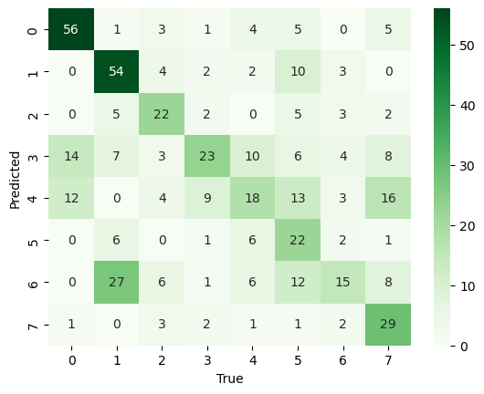

```python
import seaborn as sns
cf = confusion_matrix(y_test, y_pred)
sns.heatmap(cf, annot=True, cmap="Greens")
plt.xlabel("True")
plt.ylabel("Predicted")
plt.show()
```

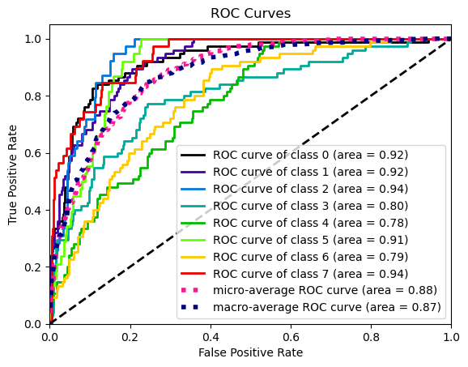

```python
import scikitplot
y_pred_proba = clf.predict_proba(X_test)
scikitplot.metrics.plot_roc(y_test,y_pred_proba)
```

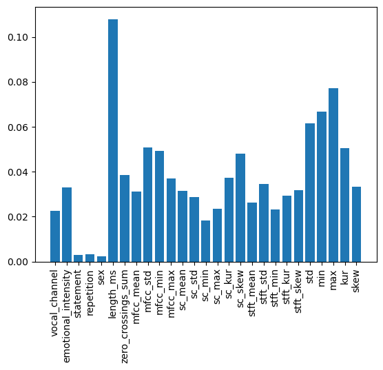

```python
plt.bar(columns, clf.feature_importances_)
plt.xticks(rotation=90)
plt.show()
```

Vediamo adesso quanti DecisionTrees sono stati usati per creare la RandomForest (100) e ne visualizziamo due (il primo e il secondo)

```python
len(clf.estimators_)
```

```
100
```

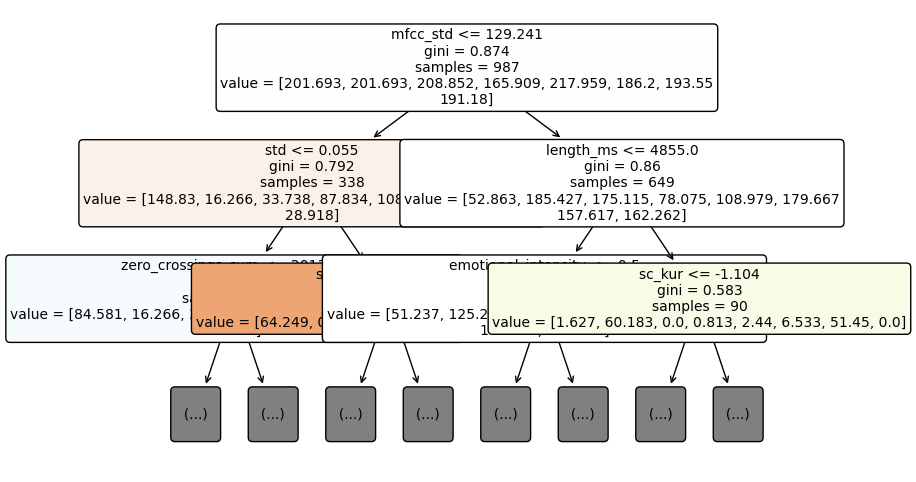

```python
plt.figure(figsize=(8, 6))
plot_tree(clf.estimators_[0],
          feature_names=columns,
          filled=True,
          rounded=True,
          fontsize=10,
          max_depth=2
          )
plt.show()
```

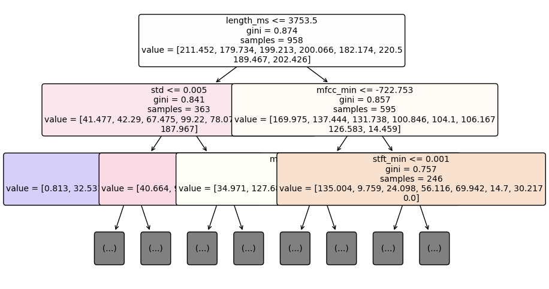

```python
plt.figure(figsize=(8, 6))
plot_tree(clf.estimators_[1],
          feature_names=columns,
          filled=True,
          rounded=True,
          fontsize=10,
          max_depth=2
          )
plt.show()
```

## SVM

Procediamo ora ad utilizzare la Support Vector Machine (SVM) sul nostro dataset. La SVM è un metodo predittivo che cerca un iperpiano per separare i dati nello spazio delle feature. Per ridurre il carico computazionale, abbiamo deciso di ridurre la dimensionalità del Training Set.

Importiamo sia LinearSVC, che effettua una separazione lineare, sia SVC, che consente l'utilizzo del kernel trick per gestire dati non linearmente separabili.

```python
from sklearn.model_selection import train_test_split
from sklearn.svm import LinearSVC, SVC
from sklearn.metrics import accuracy_score
from sklearn.model_selection import RandomizedSearchCV
```

```python
target = 'Emotion_val'
columns = [c for c in dfe_noobj.columns if c not in ['Emotion_val','sex','emotional_intensity','statement','repetition', 'vocal_channel']]
```

```python
X = dfe_noobj[columns].values
y = dfe_noobj[target].values
```

```python
X_train_val, X_test, y_train_val, y_test = train_test_split(X, y, test_size=0.2, stratify=y, random_state=0)
X_train, X_val, y_train, y_val = train_test_split(X_train_val, y_train_val, test_size=0.2, stratify=y_train_val, random_state=0)
```

```python
lin_svm = LinearSVC(C=1,max_iter=5000, dual=False)
lin_svm.fit(X_train_val, y_train_val)
y_pred = lin_svm.predict(X_test)
accuracy_score(y_test, y_pred)
```

```
0.37067209775967414
```

```python
svm = SVC(C=100, kernel='poly')
svm.fit(X_train_val, y_train_val)
y_pred = svm.predict(X_test)
accuracy_score(y_test, y_pred)
```

```
0.3258655804480652
```

Possiamo valutare la tipologia di Kernel e il parametro C attraverso l'**HYPERPARAMETER TUNING** durante la fase di validazione con una RandomizedSearch. Rispetto a un tentativo iniziale abbiamo ristretto il range dei parametri e il numero di iterazioni per ridurre il carico computazionale. Abbiamo anche settato il parametro n_jobs=-1 che permette di fare più calcoli in parallelo su più core potenzialmente aumentando la velocità di calcolo.

```python
param_dict = {
    'C': [0.1, 10, 100],
    'kernel': ['linear','poly','rbf'],
    'degree': [1, 2, 4, 5],
    'gamma': ['scale', 'auto'],
    'coef0': [0.0, 1, 10],
}

clfSCV = SVC()

rands = RandomizedSearchCV(clf, param_dict, cv=5, scoring='accuracy', refit=True, n_iter=50, random_state=0,n_jobs=-1)

rands.fit(X_train_val, y_train_val)

print("Best parameters:", rands.best_params_)

clf = rands.best_estimator_

clf.fit(X_train_val, y_train_val)

y_pred = clf.predict(X_test)

accuracy = accuracy_score(y_test, y_pred)
print(f'Accuracy: {accuracy:.4f}')
```

## Classification - Discussion and Conclusions

In questa sezione abbiamo esplorato l'utilizzo di alcuni modelli di classificazione per prevedere due specifiche variabili del nostro dataset: "Sex" ed "Emotion". Ogni modello ha offerto spunti di riflessione e in particolare sulla performance in termini di accuratezza e precisione.

Nel caso della variabile target Sex, sia il Decision Tree che il KNN hanno dato ottimi risultati con accuratezze intorno al 90%. Nonostante questa similarità, il KNN sembra essere migliore del Decision Tree non solo perché la sua accuratezza è leggermente più alta, ma anche perché la precision sulle due classi è meno sbilanciata. Questo può essere attribuito alle sue caratteristiche intrinseche. Il KNN, essendo un algoritmo basato sulla distanza, tende a essere più flessibile e meno incline all'overfitting rispetto ai Decision Trees. Inoltre, la capacità del KNN di mantenere una precisione equilibrata tra le classi suggerisce che gestisce meglio il problema dello sbilanciamento delle classi senza necessità di tecniche aggiuntive.

Se volessimo prevedere una classe specifica di Emotion, potremmo usare le seguenti strategie:

1. Scegliere il metodo con la migliore precisione per la classe d'interesse (o altre metriche di valutazione a seconda di quello su cui vogliamo focalizzarci).
2. Lavorare sulla class_weight delle classi durante la fase di allenamento del modello
3. Identificare e utilizzare le feature che esercitano maggiore influenza sulla predizione della classe di interesse, ottimizzando così le prestazioni del modello su quella specifica categoria.
4. Validazione incrociata e tuning degli iperparametri focalizzandoci su una classe specifica

In conclusione, la scelta del modello migliore dipende dall'obiettivo specifico, dalla natura dei dati e dalla distribuzione delle classi, richiedendo una valutazione per bilanciare accuratezza generale e distribuzione tra le classi.